# Named Probability Distributions

Yuji Saikai ysaikai@unimelb.edu.au School of Mathematics and Statistics The University of Melbourne

26 April 2021

These notes are based on Chapter 16 of Jones, O., Maillardet, R., & Robinson, A. (2009). *Introduction to scientific programming and simulation using R*. CRC Press.

# Continuous distributions

R recognises common distributions by short names and specifies them by parameters.

| Distribution | R name | R Parameters | Abbreviation |
| --- | --- | --- | --- |
| Uniform | `unif` | `min`, `max` | $\mathrm{U}(a,b)$ |
| Exponential | `exp` | `rate` | $\exp(\lambda)$ |
| Weibull | `weibull` | `shape`, `scale` | $\mathrm{weibull}(m,\lambda)$ |
| Gamma | `gamma` | `shape`, `rate` | $\text{gamma}(m,\lambda)$ |
| Normal | `norm` | `mean`, `sd` | $\mathrm{N}(\mu,\sigma^2)$ |

R built-in functions for common distributions follow a certain pattern. Suppose that a distribution is recognised by name `xyz` and specified by parameters `p1` and `p2`, then R provides the following four functions to help you work with the distribution.

- `dxyz(x, p1, p2, ...)` returns $f(x)$, the value of PDF at $x$.
- `pxyz(q, p1, p2, ...)` returns $F(q)$, the value of CDF at $q$.
- `qxyz(p, p1, p2, ...)` returns $\operatorname{argmin}_x F(x)\geq p$, i.e., the [quantile function](https://en.wikipedia.org/wiki/Quantile_function).
- `rxyz(n, p1, p2, ...)` returns $n$ random samples.

## Uniform

$X\sim \mathrm{U}(a,b)$ if the support of $X$ is an interval $[a,b]$ and the density is independent of location $x$.

Deriving the PDF of $X$ highlights key ideas common in many continuous distributions. The ideas to recall are:

- $f(x)$ is equal to $0$ for $x$ outside the support,
- $f(x)$ integrates to $1$ over the real line.

Given $X\sim \mathrm{U}(a,b)$, let $c=f(x)$ for $x\in[a,b]$. Then,
$$f(x) =
\begin{cases}
c & \text{if } x\in[a,b]\\
0 & \text{otherwise}
\end{cases}$$
It follows:

$$\begin{alignat}{2}
& & \int_{-\infty}^\infty f(x)dx &= 1\\
&\Leftrightarrow\quad & \int_a^b cdx &= 1\\
&\Leftrightarrow\quad & c(b-a) &= 1\\
&\Leftrightarrow\quad & c &= \frac{1}{b-a}
\end{alignat}$$

Just like the role $\mathrm{Bernoulli}(p)$ plays in constructing discrete distributions, as you will see in Sampling Methods, $\mathrm{U}(0,1)$ is a fundamental device for sampling from pretty much any distribution *in silico*.

## Exponential

$X\sim \mathrm{exp}(\lambda)$ has the following PDF:
$$f(x) =
\begin{cases}
\lambda e^{-\lambda x} & \text{if } x\geq0\\
0 & \text{otherwise}
\end{cases}$$
with **rate** parameter $\lambda>0$.

The CDF is equal to $0$ for $x<0$ and, for $x\geq0$,
$$\begin{align}
F(x) &= \int_{-\infty}^x f(t)dt\\
&= \int_0^x \lambda e^{-\lambda t} dt\\
&= 1-e^{-\lambda x}
\end{align}$$

In practice, $\mathrm{exp}(\lambda)$ is often used to model **waiting time**. For given waiting time $x$, large $\lambda$ implies fast arrival rate and high probability of arrival, indicated by $F(x)$ as an increasing function of $\lambda$.

In contrast, given any arrival rate $\lambda$, if we wait forever ($x\to\infty$), it almost surely arrives as indicated by $F(x)\to 1$.

### Memoryless property

Unique to $\mathrm{exp}(\lambda)$ is the so-called momoryless property, which can be expressed as follows.
$$P(X>t+s | X>t) = P(X>s) \;\text{ for } s,t>0 .$$

A proof simple.
$$\begin{align}
P(X>t+s | X>t) &= \frac{P(X>t+s, X>t)}{P(X>t)}\\
&= \frac{P(X>t+s)}{P(X>t)}\\
&= \frac{e^{-\lambda(t+s)}}{e^{-\lambda(t)}}\\
&= e^{-\lambda s}\\
&= P(X>s)
\end{align}$$

To illustrate, let’s use $\mathrm{exp}(\lambda)$ to model the waiting time for an elevator. Suppose $\lambda = 0.5$. Then, the probability that an elevator arrives within 4 minutes, is $F(4) = 0.86$.

Today is your bad day, and it has not come after waiting for 4 minutes. Now, you wonder “Since I already waited for so long and I know $F(5) = 0.92$ (nerd!), it will very likely come within a minute.”

The memoryless property says “Not really. It will come only with $F(1) = 0.39$ chance.” In other words, if your mental model relies on $\mathrm{exp}(\lambda)$, the fact that you have already waited for so long is totally irrelevant.

## Weibull

When modelling arrival of bad things (e.g., mechanical failure or disaster), we often phrase it as **survival**, simply meaning the negation of arrival. In probabilistic terms, if $F(x)$ is the probability that a failure happens by the time $x$, $1-F(x)$ is the probability of survival until the time $x$.

While $\mathrm{exp}(\lambda)$ can be used, $\mathrm{weibull}(m,\lambda)$ provides a more general framework, which is often more suitable for survival analysis. The PDF $f(x)$ and CDF $F(x)$ are given below.

$$\begin{align}
f(x) &=
\begin{cases}
m\lambda x^{m-1}e^{-\lambda x^m} & \text{if } x\geq0\\
0 & \text{otherwise}
\end{cases}\\\\
F(x) &=
\begin{cases}
1 - e^{-\lambda x^m} & \text{if } x\geq0\\
0 & \text{otherwise}
\end{cases}\\\\
\end{align}$$

$\mathrm{weibull}(m,\lambda)$ generalises the **constant** rate $\lambda$ used in $\mathrm{exp}(\lambda)$ to a **function** $\lambda(x) = m\lambda x^{m-1}$, which covers the constant case at $m=1$. This time-varying rate $\lambda(x)$ is commonly referred to as a **hazard function**.

### Hazard function

For $\mathrm{exp}(\lambda)$, the rate parameter $\lambda$ is assumed to be constant. What if our real-world problems suggest that the arrival/survival rate is not constant but depends on $x$?

We begin with the CDF of $\mathrm{exp}(\lambda)$:
$$F(x) = 1-e^{-\lambda x} .$$
Recall that $\lambda$ captures a **rate** (e.g., a derivative or a change for an infinitesimal time), and $F(x)$ is the probability of occurrence by the time $x$, which goes to $1$ as $x\to\infty$. This observation suggests that $\lambda x$ is the result of integration, $\lambda x = \int_0^x \lambda dt$.

Now, let’s explicitly write $\lambda(x)$ as a function of $x$. As long as we make sure $\int_0^x \lambda(t) dt$ is an increasing function of $x$, we have a legitimate $F(x)$ such that
$$\lim_{x\to\infty}F(x) = \lim_{x\to\infty}\left[1-\exp\left(-\int_0^x \lambda(t)dt\right)\right] = 1 .$$

With this CDF, the PDF can be derived using the chain rule and the fundamental theorem of calculus.

$$\begin{align}
f(x) &= F'(x)\\
&= \frac{d}{dx}\left[1-\exp\left(-\int_0^x \lambda(t)dt\right)\right]\\
&= \lambda(x)\exp\left(-\int_0^x \lambda(t)dt\right),
\end{align}$$

which is the PDF of $\mathrm{weibull}(m,\lambda)$ if $\lambda(x) = m\lambda x^{m-1}$.

### R parameterisation

This is unfortunately confusing but important to note. The R parameterisation of the Weibull distribution differs from that presented here. `shape` parameter in R simply corresponds to $m$. But, `scale` in R corresponds to $\lambda^{-1/m}$.

For example, to simulate $\mathrm{weibull}(m,\lambda)$ with $m=0.5$ and $\lambda=2$, give

- `shape=0.5`
- `scale=2^(-1/0.5)`

to each of R built-in functions for $\mathrm{weibull}(m,\lambda)$.

## Gamma

As seen in Exponential, $\text{exp}(\lambda)$ is commonly used to model waiting time. Dividing the continuous time line into small intervals of equal length, we may model waiting-time problems using $\text{geom}(p)$, which is a sequence of IID $\text{Bernoulli}(p)$. That is, at each interval, $\text{Bernoulli}(p)$ represents an occurrence of arrival.

Remember that if we add $r$ number of IID $\text{geom}(p)$, we get $\text{nbinom}(r,p)$. Therefore, it is natural to wonder what if we add $m$ number of IID $\text{exp}(\lambda)$. The answer is $\text{gamma}(m,\lambda)$.

Let $X = Y_1+\dots+Y_m$ such that $Y_i\sim\text{exp}(\lambda)$ for all $i\in\{1,\dots,m\}$. Then, $X$ follows $\text{gamma}(m,\lambda)$.

## Normal

Because of its incredible analytical properties, normal distribution is arguably the most important probability distribution. To highlight just two of those properties, we use random vector which are jointly distributed as normal.

> Scalar $X\sim \mathrm{N}(\mu,\sigma^2)$ is a special case. By now, you should be capable of using R built-in functions for `norm`.

Let $\boldsymbol{\mu}$ be the mean vector of length $n$ and $\mathbf{\Sigma}$ be the $n\times n$ covariance matrix (hence, **positive-semidefinite**).

### Property 1

Let $\mathbf{Z}$ be the standardised $\mathbf{X}$, namely, $\mathbf{Z}\sim \mathrm{N}(\mathbf{0},\mathbf{I}_m)$, where $\mathbf{I}_m$ is the $m\times m$ identity matrix. Then, there exist a $n\times m$ matrix $\mathbf{A}$ such that $\mathbf{A}\mathbf{A}'=\mathbf{\Sigma}$ and
$$\mathbf{X} = \mathbf{A}\mathbf{Z}+\boldsymbol{\mu} .$$

An implication is that since $\mathbf{Z}$ is merely $m$ independent $\mathrm{N}(0,1)$ stacked as a vector, it is easy to simulate $\mathbf{Z}$ and thereby simulating $\mathbf{X}$.

To generate a sample $\mathbf{x}$ of $\mathbf{X}$ with your desirable $\boldsymbol{\mu}$ and $\mathbf{\Sigma}$,

1. Decompose $\mathbf{\Sigma}$ into $\mathbf{A}$ and $\mathbf{A}'$ (typically via Cholesky decomposition),
2. Simulate $\mathrm{N}(0,1)$ $n$ times and stack them as $\mathbf{z}$,
3. Compute $\mathbf{x} = \mathbf{A}\mathbf{z}+\boldsymbol{\mu}$.

> Yes, of course, there’s a package for that! But, it is quite fulfilling to know a sampling algorithm for such an important random vector. Once you get it and test your own, you may use function `mvrnorm` from `MASS` package.

### Property 2

The second property is, in words, *a linear transformation of $\mathbf{x}$ is also normal*.

Let $\mathbf{C}$ be a $m\times n$ matrix. Then,
$$\mathbf{C}\mathbf{X} \sim \mathbf{N}(\mathbf{C}\boldsymbol{\mu}, \mathbf{C}\mathbf{\Sigma}\mathbf{C}') .$$

For example, if $\mathbf{C} = (c_1\;c_2\;\dots\;c_n)$ is a $1\times n$ matrix, then we have the sum $\mathbf{C}\mathbf{X} = c_1X_1+c_2X_2+\dots+c_nX_n$.

Furthermore, if $\mathbf{\Sigma}$ is a diagonal or $\mathbf{X}$ is formed by stacking $n$ independent $\mathrm{N}(\mu_i,\sigma_i^2)$, then we have a common statement — *the sum of independent normals is normal*.

### Joint PDF

If $\mathbf{\Sigma}$ is a $n\times n$ **positive-definite** covariance matrix, then normal random vector $\mathbf{X} \sim \mathrm{N}(\boldsymbol{\mu},\mathbf{\Sigma})$ has a joint PDF:
$$f(\mathbf{x}) = (2\pi)^{-\frac{n}{2}}|\mathbf{\Sigma}|^{-\frac{1}{2}}\exp\left(-\frac{1}{2}(\mathbf{x}-\boldsymbol{\mu})'\mathbf{\Sigma}^{-1}(\mathbf{x}-\boldsymbol{\mu})\right)$$
where $|\mathbf{\Sigma}|$ is the determinant of $\mathbf{\Sigma}$.

# Poisson process

The Poisson process is, in many ways, a continuous-time analogue of the Bernoulli process, namely a sequence of independent Bernoulli trials, which we use to motivate Binomial, Geometric, and Negative binomial.

Here is a summary of correspondences between discrete-time and continuous-time analogues in different modelling contexts.

| Context | Discrete time | Continuous time |
| --- | --- | --- |
| Number of arrivals | Binomial | Poisson |
| Time to an arrival | Geometric | Exponential |
| Time to multiple arrivals | Negative binomial | Gamma |
| Arrival process | Bernoulli process | Poisson process |

Let’s use the Bernoulli process to motivate the Poisson process.

## Discrete-time arrival process

Let $\{B_i\}$ be the Bernoulli process, where each of IID trials is $B_i\sim\text{Bernoulli}(p)$. We may interpret the Bernoulli process in the following way:

- Index $i>0$ represents a time slot of equal length.
- At each slot, $\text{Bernoulli}(p)$ trial takes place.
- $B_i=1$ represents “arrival” (previously, “success”).

A discrete-time arrival process is a sequence $S_1,S_2,\dots$ of arrival time slots; that is, in $S_j$ time slot, the $j$th arrival occurs (hence, $S_j\geq j$ and $S_j=j$ only if arrival happens in every slot up to $j$).

There is another associated counting process $\{N(t) : t>0\}$, where $N(t)$ gives the number of arrivals up to time slot $t$ inclusive. Thus, for given $t$, $N(t) \sim \text{binom}(t,p)$. ($t$ here is a positive integer and plays a role of $i$.)

Finally, there is also associated sequence $X_1,X_2,\dots$ of interarrival time slots, each of which follows $\text{geom}(p)$. (N.B. This $\text{geom}(p)$ is the number of *trials* instead of *failure* as we define above.) It turns out that this last sequence of $\text{geom}(p)$ alone can fully specifies the Bernoulli process. That is, given $\{X_j\}$, $S_k = \sum_{j=1}^kX_j$ for all $k\geq1$, which in turn tells us when each arrival occurs.

The reason for focusing on $\{X_j\}$ is because it is an IID process and much easier to define the joint distribution than $\{S_j\}$.

A mental picture looks like this:

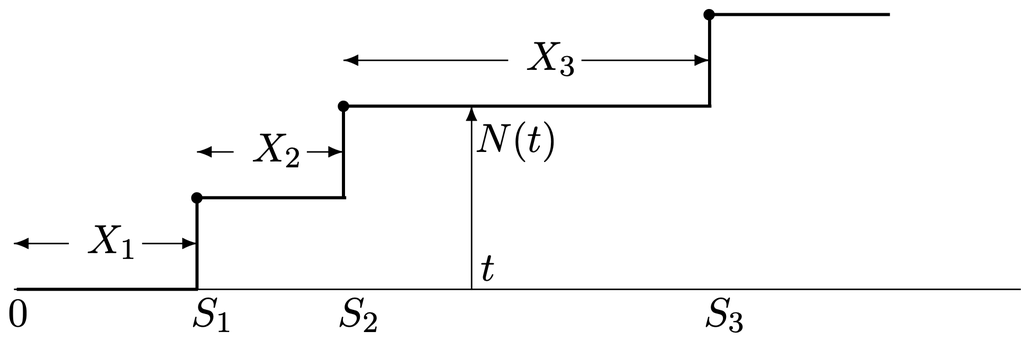

From now on, consider everything in continuous time. Perhaps, you may think that, in the discrete-time setting, we check whether an arrival happens exactly every minute. But, now we can continuously monitor arrivals.

## Definition & properties

The Poisson process is a (continuous-time) arrival process $\{S_j\}$ where each of the interarrival time follows an IID exponential distribution, i.e., $X_j\sim\text{exp}(\lambda)$ for all $j\in\mathbb{Z}_{>0}$.

### Property 1

$N(t)$, the number of arrivals in $[0,t]$, follows $\text{pois}(\lambda t)$ with the PMF of
$$P(N(t)=n) = \frac{e^{-\lambda t}(\lambda t)^n}{n!} .$$
$\{N(t) : t\geq0\}$ is called the Poisson counting process.

*Proof*. A key observation is that $N(t)=n$ if and only if $S_n \leq t < S_{n+1}$ because the $n$th arrival occurs before time $t$ but the $(n+1)$th after $t$. We will break things down according to the value of $s := S_n \in [0,t]$.

To compute the probability of the event $N(t)=n$, first notice that, for $S_{n+1}>t$, we need $X_{n+1}>t-s$. Second, by definition, $X_{n+1}$ is independent of $X_n,\dots,X_n$ and therefore independent of $S_n$. Now, we have
$$\begin{align}
P(N(t)=n)
&= \int_0^t f_{S_n}(s) P(X_{n+1}>t-s)ds\\
&= \int_0^t \lambda e^{-\lambda s}\frac{(\lambda s)^{n-1}}{(n-1)!}\cdot e^{-\lambda(t-s)}ds\\
&= \frac{(\lambda)^{n}}{(n-1)!}e^{-\lambda t} \int_0^t s^{n-1}ds\\
&= \frac{e^{-\lambda t}(\lambda t)^{n}}{n!}
\end{align}$$

> Recall $S_n=X_1+\dots+X_n$ follows $\text{gamma}(n,\lambda s)$.

### Property 2

For $s\geq0$, $N(s+t)-N(t)$ also follows $\text{pois}(\lambda s)$.

*Proof*. Suppose that, by time $t$, there have been $n$ arrivals at time $s_1, \dots, s_n$. We know $X_{n+1}>t-s_n$. In addition, by the memoryless property of $\text{exp}(\lambda)$,
$$P(X_{n+1}>t-s_n+s | X_{n+1}>t-s_n) = P(X_{n+1}>s) = e^{-\lambda s}.$$
This implies that the distribution of the first arrival **after $t$** also follows $\text{exp}(\lambda)$ and independent of $S_1,\dots,S_n$. It is also the case that $X_{n+2}, X_{n+3},\dots$ are independent of $S_1,\dots,S_n$ and $X_{n+1}$. Consequently, a sequence of interarrival times after $t$ is an IID $\text{exp}(\lambda)$ and forms a Poisson process.

### Property 3

$N(t)$ has independent increments; i.e., for $t_0<t_1<\dots<t_n$,
$$N(t_1)-N(t_0), N(t_2)-N(t_1),\dots,N(t_n)-N(t_{n-1})$$
are independent.

*Proof*. Property 2 implies that $N(t_n)-N(t_{n-1})$ is independent of $N(s)$ for $s\leq t_{n-1}$ and therefore independent of $N(t_{n-1})-N(t_{n-2}), \dots, N(t_1)-N(t_0).$

## Application

If you run a tech company to provide online services (e.g., shopping and banking), you need computer servers to respond to customers’ requests. These days, it has become quite popular to rent, rather than buy, computing infrastructure in the cloud. Just like your mobile phone contracts, you want to rent a right amount of the infrastructure. To figure out the right amount, you need models of customers’ requests.

Let’s take one step at a time.

1. Model how many customers arrive each day.
2. Model how many requests each customer makes.

Combining them, we have a random variable for the number of request per day. Most likely, we are interested in its mean and variance.

- Let $N$ be a random variable with the support of $\mathbb{Z}_{\geq0}$ for the number of customers.
- Let $Y_1,Y_2,\dots$ are IID random variables such that $Y_i$ is the number of requests $i$th customer makes.
- Let $S = Y_1+\dots+Y_N$ and $S=0$ when $N=0$. This is of our interest.
- Assume $N$ and each $Y_i$ are independent.

Then, implications are:

1. $\mathbb{E}S = \mathbb{E}N \cdot \mathbb{E}Y_i$ provided $\mathbb{E}|Y_i|, \mathbb{E}N < \infty$.
2. $\operatorname{Var} S = \mathbb{E}N \cdot \operatorname{Var} Y_i + \operatorname{Var} N \cdot (\mathbb{E}Y_i)^2$ provided $\mathbb{E}Y_i^2, \mathbb{E}N^2 < \infty$.
3. If $N\sim\text{pois}(\lambda)$, then $\operatorname{Var} S = \lambda\mathbb{E}(Y_i)^2$.

Proof for (i).
$$\begin{align}
\mathbb{E}S &= \sum_{n=0}^\infty \mathbb{E}[S|N=n]\cdot P(N=n)\\
&= \sum_{n=0}^\infty \mathbb{E}[Y_1+\dots+Y_n|N=n]\cdot P(N=n)\\
&= \sum_{n=0}^\infty n\mathbb{E}Y_i \cdot P(N=n)\\
&= \mathbb{E}N \cdot \mathbb{E}Y_i
\end{align}$$

Proof for (ii). First, for given $N=n$,
$$\begin{align}
\mathbb{E}[S^2|N=n] &= \operatorname{Var}(S|N=n) + (\mathbb{E}[S|N=n])^2\\
&= n\operatorname{Var}Y_i + n^2(\mathbb{E}Y_i)^2
\end{align}$$

Then,
$$\begin{align}
\mathbb{E}S^2 &= \sum_{n=0}^\infty \mathbb{E}[S^2|N=n]\\
&= \sum_{n=0}^\infty \left[n\operatorname{Var}Y_i + n^2(\mathbb{E}Y_i)^2\right] \cdot P(N=n)\\
&= \mathbb{E}N\cdot\operatorname{Var}Y_i + \mathbb{E}N^2\cdot(\mathbb{E}Y_i)^2
\end{align}$$

As a result,
$$\begin{align}
\operatorname{Var}S &= \mathbb{E}S^2 - (\mathbb{E}S)^2\\
&= \mathbb{E}N\cdot\operatorname{Var}Y_i + \mathbb{E}N^2\cdot(\mathbb{E}Y_i)^2 - (\mathbb{E}N \cdot \mathbb{E}Y_i)^2\\
&= \mathbb{E}N\cdot\operatorname{Var}Y_i + \operatorname{Var}N \cdot (\mathbb{E}Y_i)^2
\end{align}$$

Proof for (iii). $N\sim\text{pois}(\lambda)$ implies $\mathbb{E}N = \lambda$ and $\operatorname{Var}N = \lambda$. Now, the result follows.

> Notice the condition in (iii) arises from assuming that the customer arrival process follows the Poisson process with rate $\lambda$.